# Hydrogen atom — Schrödinger equation and radial solutions

Author

Daniel Fischer

# Hydrogen atom: overview and plan

We solve the time-independent Schrödinger equation for a single electron in the Coulomb potential of a nucleus (atomic number $Z$). The goals of this chapter are:

1. Re-express the Hamiltonian using the angular-momentum operator $\hat{\vec L}$.
2. Separate variables in spherical coordinates and reduce the problem to a radial ordinary differential equation (ODE).
3. Solve the radial ODE for bound states ($E<0$), perform the asymptotic analysis, obtain the quantization condition, and write the normalized eigenfunctions.

# 1. Hamiltonian and the angular-momentum form

The non-relativistic time-independent Hamiltonian for an electron–proton system (masses $m$ and $M$, respectively) interacting via the Coulomb potential is

$$\hat H = -\frac{\hbar^2}{2m}\nabla_e^2 -\frac{\hbar^2}{2M}\nabla_p^2 + V(r).$$

Here  
- $\nabla_e = \big(\tfrac{\partial}{\partial x_e}, \tfrac{\partial}{\partial y_e}, \tfrac{\partial}{\partial z_e}\big)$ is the gradient with respect to the **electron coordinates** $\vec r_e$,  
- $\nabla_p = \big(\tfrac{\partial}{\partial x_p}, \tfrac{\partial}{\partial y_p}, \tfrac{\partial}{\partial z_p}\big)$ is the gradient with respect to the **proton coordinates** $\vec r_p$.

For the hydrogen(-like) atom the potential is Coulombic:

$$V(r) = -\frac{Z e^2}{4\pi\varepsilon_0}\,\frac{1}{r},$$

where $Z$ is the nuclear charge ($Z=1$ for hydrogen), $e$ the elementary charge, $\varepsilon_0$ the vacuum permittivity, and $r = |\vec r_e - \vec r_p|$ is the distance between the electron and the proton.

## 1.1 Center of Mass and Relative Motion

It is convenient to switch from the electron and proton coordinates $(\vec r_e, \vec r_p)$ to

- the **center-of-mass coordinate**
  $$\vec R = \frac{m \vec r_e + M \vec r_p}{m+M},$$
- and the **relative coordinate**
  $$\vec r = \vec r_e - \vec r_p.$$

In these new variables the Hamiltonian separates into two parts:

$$\hat H = -\frac{\hbar^2}{2(m+M)} \nabla_R^2
-\frac{\hbar^2}{2\mu} \nabla_r^2
+ V(r),$$

where

$$\mu = \frac{mM}{m+M}$$

is the **reduced mass** of the electron–proton system.

The term
$$-\frac{\hbar^2}{2(m+M)}\nabla_R^2$$
describes the free motion of the atom as a whole through space. Since spectroscopy and bound-state problems are only sensitive to the **internal dynamics**, this center-of-mass contribution can be ignored (or factored out as a plane wave).

## 1.2 Effective One-Body Hamiltonian

Thus, for studying the hydrogen spectrum we keep only the relative motion:

$$\hat H = -\frac{\hbar^2}{2\mu}\nabla_r^2
-\frac{Z e^2}{4\pi\varepsilon_0}\,\frac{1}{r}.$$

This is the familiar hydrogen Hamiltonian, except that the electron mass $m$ is replaced by the reduced mass $\mu$.

For hydrogen, since $M \gg m$, one has $\mu \approx m$, but the correction is important for **high-precision spectroscopy**.

## 1.3 The Laplacian and $\hat L^2$

We will rewrite the Laplacian in spherical coordinates and express the angular part in terms of $\hat L^2$.

In spherical coordinates $(r,\theta,\varphi)$ the Laplacian acting on a scalar $\psi(r,\theta,\varphi)$ reads

$$\nabla^2 \psi
= \frac{1}{r^2}\frac{\partial}{\partial r}\!\Big(r^2\frac{\partial \psi}{\partial r}\Big)
+ \frac{1}{r^2}\Bigg[\frac{1}{\sin\theta}\frac{\partial}{\partial\theta}\!\Big(\sin\theta\frac{\partial \psi}{\partial\theta}\Big)
+ \frac{1}{\sin^2\theta}\frac{\partial^2\psi}{\partial\varphi^2}\Bigg].$$

Recall the angular momentum squared operator in coordinate representation:

$$\hat L^2 = -\hbar^2\left[
\frac{1}{\sin\theta}\frac{\partial}{\partial\theta}\!\Big(\sin\theta\frac{\partial}{\partial\theta}\Big)
+ \frac{1}{\sin^2\theta}\frac{\partial^2}{\partial\varphi^2}
\right].$$

Comparing the two expressions gives the useful identity (acting on any $\psi$)

$$\nabla^2 = \frac{1}{r^2}\frac{\partial}{\partial r}\!\Big(r^2\frac{\partial}{\partial r}\Big) - \frac{1}{\hbar^2 r^2}\,\hat L^2 .$$

Insert this into the kinetic term of the Hamiltonian to obtain

$$\begin{aligned}
-\frac{\hbar^2}{2\mu}\nabla^2
&= -\frac{\hbar^2}{2\mu}\frac{1}{r^2}\frac{\partial}{\partial r}\!\Big(r^2\frac{\partial}{\partial r}\Big)
+ \frac{\hat L^2}{2 \mu r^2}.
\end{aligned}$$

Therefore the full Hamiltonian becomes

$$\hat H = -\frac{\hbar^2}{2\mu}\frac{1}{r^2}\frac{\partial}{\partial r}\!\Big(r^2\frac{\partial}{\partial r}\Big)
+ \frac{\hat L^2}{2 \mu r^2} + V(r)$$

# 2. Separation of variables: angular and radial parts

Because the Coulomb potential depends only on the distance $r$, the Hamiltonian commutes with the angular momentum operators:

$$[\hat H, \hat L^2] = 0,
\qquad
[\hat H, \hat L_z] = 0.$$

This means that $\hat H$, $\hat L^2$, and $\hat L_z$ have a common set of eigenfunctions. In particular, the wavefunction can be chosen to be a simultaneous eigenfunction of $\hat L^2$ and $\hat L_z$, which motivates a separation of variables into radial and angular parts:

$$\psi(r,\theta,\varphi) = R(r)\, Y_\ell^m(\theta,\varphi),$$

where $Y_\ell^m(\theta,\varphi)$ are spherical harmonics satisfying

$$\hat L^2 Y_\ell^m = \hbar^2 \ell(\ell+1) Y_\ell^m,
\qquad
\hat L_z Y_\ell^m = \hbar m Y_\ell^m.$$

Inserting the separated form into $\hat H\psi=E\psi$ and using the Hamiltonian above yields the radial equation

$$-\frac{\hbar^2}{2\mu}\frac{1}{r^2}\frac{d}{dr}\!\Big(r^2\frac{dR}{dr}\Big)
+ \frac{\hbar^2 \ell(\ell+1)}{2 \mu r^2} R(r) + V(r) R(r) = E R(r).$$

## 2.1 The rotational (centrifugal) barrier

The term

$$\frac{\hbar^2 \ell(\ell+1)}{2 \mu r^2}$$

originates from the angular part of the kinetic energy. It acts like an effective potential that depends on $\ell$.

- For $\ell=0$, this term vanishes, and the particle can access the region near $r=0$.
- For $\ell>0$, the term grows rapidly as $r\to 0$, suppressing the radial wavefunction in the vicinity of the origin.

This is often called the *centrifugal barrier*. Classically, it reflects the fact that angular motion produces an effective outward “force.” Quantum mechanically, it makes it harder for states with high angular momentum to penetrate the central region.

## 2.2 Convert to the reduced radial equation

Define the reduced radial function

$$u(r) = r\, R(r).$$

It is straightforward to check that

$$\frac{1}{r^2}\frac{d}{dr}\!\Big(r^2\frac{dR}{dr}\Big)
= \frac{1}{r}\frac{d^2}{dr^2}\big(r R\big)
= \frac{1}{r}\frac{d^2 u}{dr^2}.$$

Substituting into the radial equation gives the convenient one-dimensional form

$$-\frac{\hbar^2}{2\mu}\frac{d^2 u}{dr^2}
+ \left[V(r) + \frac{\hbar^2 \ell(\ell+1)}{2\mu r^2}\right] u(r) = E\, u(r).$$

This is exactly the time-independent Schrödinger equation for a one-dimensional motion of $u(r)$ on the half-line $r\in(0,\infty)$ with the *effective potential*

$$V_{\text{eff}}(r) = V(r) + \frac{\hbar^2 \ell(\ell+1)}{2\mu r^2}.$$

The boundary condition at the origin is $u(0)=0$ (regularity) and $u(r)$ must be square integrable on $(0,\infty)$.

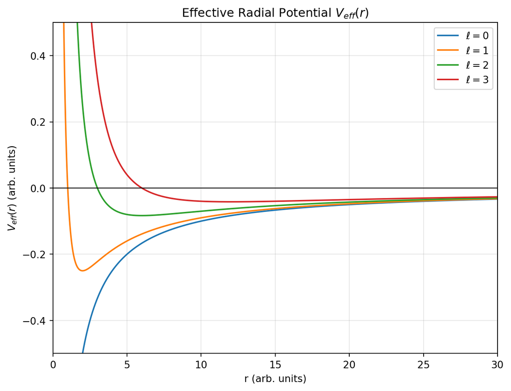

Figure 1: Effective radial Coulomb potential for different angular momenta.

```python
import numpy as np
import matplotlib.pyplot as plt

# Parameters (scaled units: ħ = m = k = 1)
hbar = 1
m = 1
k = 1   # corresponds to e^2/(4πϵ0)

# Define radial coordinate
r = np.linspace(0.1, 30, 1000)  # avoid r=0 to prevent singularity

def V_eff(r, ell):
    centrifugal = hbar**2 * ell * (ell + 1) / (2 * m * r**2)
    coulomb = -k / r
    return coulomb + centrifugal

# Plot effective potentials for different l
ells = [0, 1, 2, 3]
plt.figure(figsize=(8,6))

for ell in ells:
    plt.plot(r, V_eff(r, ell), label=f"$\ell={ell}$")

plt.ylim(-0.5, 0.5)
plt.xlim(0, 30)
plt.axhline(0, color='black', linewidth=0.8)
plt.title("Effective Radial Potential $V_{eff}(r)$")
plt.xlabel("r (arb. units)")
plt.ylabel("$V_{eff}(r)$ (arb. units)")
plt.legend()
plt.grid(True, alpha=0.3)
plt.show()
```

# 3. Specialize to the Coulomb potential (hydrogen-like atom)

Set

$$V(r) = -\frac{Z e^2}{4\pi\varepsilon_0}\,\frac{1}{r}.$$

The reduced radial ODE becomes

$$-\frac{\hbar^2}{2\mu}\frac{d^2 u}{dr^2}
+ \left[ -\frac{Z e^2}{4\pi\varepsilon_0}\,\frac{1}{r} + \frac{\hbar^2 \ell(\ell+1)}{2\mu r^2}\right] u(r) = E\, u(r).$$

We seek square-integrable bound-state solutions ($E<0$). The standard method proceeds in three steps: (A) analyze asymptotic behavior at $r\to 0$ and $r\to\infty$, (B) extract the dominant factors and reduce to a power-series equation, and (C) impose termination of the series to get quantized energies.

## 3.1 Asymptotic behavior

**As $r\to\infty$**: the Coulomb potential is negligible compared to $E<0$, so the equation approximates

$$-\frac{\hbar^2}{2\mu}\frac{d^2 u}{dr^2} \approx E\, u .$$

Since $E<0$, set

$$\kappa = \sqrt{\frac{-2\mu E}{\hbar^2}}\quad (>0),$$

and $u(r)\sim e^{-\kappa r}$ as $r\to\infty$ (the exponentially growing solution is discarded for normalizability).

**As $r\to 0$**: the dominant term is the centrifugal term $\propto 1/r^2$. Neglecting the Coulomb term for small $r$ gives

$$-\frac{\hbar^2}{2\mu}\frac{d^2 u}{dr^2} + \frac{\hbar^2\ell(\ell+1)}{2\mu r^2} u \approx 0.$$

Solving the indicial equation yields the leading behavior $u(r)\sim r^{\ell+1}$ (the second independent solution behaves like $r^{-\ell}$ and is non-physical because it is not regular at the origin). Therefore

$$R(r) = \frac{u(r)}{r} \sim r^{\ell} \quad (r\to 0).$$

## 3.2 Polynomial Ansatz and reduced equation

From the asymptotic analysis we propose

$$u(r) = r^{\ell+1} e^{-\kappa r} v(r),$$

where $v(r)$ should be regular everywhere. Substituting this form into the full radial equation and using the dimensionless variable

$$\rho = 2\kappa r,$$

one finds that $v(\rho)$ satisfies

$$\rho \frac{d^2 v}{d\rho^2} + (2\ell + 2 - \rho)\frac{dv}{d\rho} +
\left( \frac{Z e^2}{2\pi \varepsilon_0 \hbar}\frac{\mu}{\kappa} - \ell - 1 \right) v = 0.$$

This is of the **confluent hypergeometric form**.

To solve, assume $v(\rho)$ can be expressed as a power series:

$$v(\rho) = \sum_{j=0}^{\infty} a_j \rho^j.$$

Substituting this into the differential equation leads to a **recurrence relation** between coefficients:

$$a_{j+1} = \frac{j + \ell + 1 - \frac{\mu Z e^2}{2\pi \varepsilon_0 \hbar^2 \kappa}}{(j+1)(j+2\ell+2)}\, a_j.$$

### Termination condition

- If the series does not terminate, the coefficients $a_j$ fall off too slowly and $v(\rho)$ grows exponentially, which spoils normalizability.
- Normalizable solutions exist only if the numerator vanishes for some finite $j=n_r$ (the **radial quantum number**). This forces the series to terminate, producing a polynomial.

Thus the termination condition is:

$$\frac{\mu Z e^2}{2\pi \varepsilon_0 \hbar^2 \kappa} = n_r + \ell + 1 \equiv n, \qquad n=1,2,3,\dots$$

where $n$ is the **principal quantum number**.

## 3.3 Energy quantization and the principal quantum number

The requirement that the power-series solution terminates at a finite order fixes the parameter $\kappa$. Using $\kappa^2 = \tfrac{-2\mu E}{\hbar^2}$, the allowed bound-state energies are

**TipBound-state energies**

$$E_n = - \frac{\mu e^4 Z^2}{2(4\pi\varepsilon_0)^2 \hbar^2}\,\frac{1}{n^2}
= -\frac{R_\mathrm{y} Z^2}{n^2}, \qquad n = 1,2,3,\dots$$

where

$$R_\mathrm{y} = \frac{\mu e^4}{2(4\pi\varepsilon_0)^2\hbar^2}$$

is the **Rydberg energy** ($R_\mathrm{y} \approx 13.6057\ \text{eV}$).

It is convenient to introduce the Bohr radius

$$a_0 = \frac{4\pi\varepsilon_0 \hbar^2}{\mu e^2},$$

so that the energy can also be written as

$$E_n = -\frac{1}{2}\frac{\mu e^4 Z^2}{(4\pi\varepsilon_0)^2 \hbar^2}\frac{1}{n^2}
= -\frac{Z^2}{2}\,\frac{\hbar^2}{\mu a_0^2}\,\frac{1}{n^2}
= -\frac{Z^2}{n^2}\,\frac{e^2}{8\pi\varepsilon_0 a_0}.$$

# 4. Radial eigenfunctions: closed form

The bound-state normalized radial functions (in SI units) are

**TipRadial wave function**

$$R_{n\ell}(r)
= N_{n\ell}\,\left(\frac{2 r}{n a_0}\right)^{\ell}
\,L_{n-\ell-1}^{2\ell+1}\!\bigg(\frac{2 r}{n a_0}\bigg)\,
e^{- r/(n a_0)}$$

where $L_{k}^{\alpha}(x)$ are associated Laguerre polynomials defined by

$$L_{k}^{\alpha}(x) = \frac{x^{-\alpha} e^{x}}{k!}
\frac{d^{\,k}}{dx^{\,k}}\!\left(e^{-x} x^{k+\alpha}\right) = \sum_{m=0}^{k} \frac{(k+\alpha)!}{(k-m)!\,(\alpha+m)!}\,\frac{(-x)^m}{m!},
\qquad k = 0,1,2,\dots ,$$

and the normalization constant is

$$N_{n\ell} = \sqrt{\left(\frac{2}{n a_0}\right)^3
\frac{(n-\ell-1)!}{2n\, (n+\ell)!}\ }.$$

The full hydrogenic stationary state is

**TipHydrogen wave function**

$$\psi_{n\ell m}(r,\theta,\varphi) = R_{n\ell}(r)\, Y_\ell^m(\theta,\varphi).$$

## 4.1 Explicit low-$n$ examples

- **1s state** $(n=1,\ell=0)$:

  $$R_{10}(r) = 2 \,a_0^{-3/2}\, e^{-r/a_0}.$$
- **2s state** $(n=2,\ell=0)$:

  $$R_{20}(r) = \frac{1}{2\sqrt{2}}\, a_0^{-3/2} \Big(2 - \frac{r}{a_0}\Big)\, e^{-r/(2 a_0)}.$$
- **2p states** $(n=2,\ell=1)$; e.g. $m=0$:

  $$R_{21}(r) = \frac{1}{2\sqrt{6}}\, a_0^{-3/2}\, \frac{r}{a_0}\, e^{-r/(2 a_0)}$$
- **3s state** $(n=3,\ell=0)$:

  $$R_{30}(r) = \frac{2}{81\sqrt{3}}\, a_0^{-3/2} \Big(27 - 18 \tfrac{r}{a_0} + 2 \big(\tfrac{r}{a_0}\big)^2\Big) e^{-r/(3a_0)}.$$
- **3p states** $(n=3,\ell=1)$; e.g. $m=0$:

  $$R_{31}(r) = \frac{4}{81\sqrt{6}}\, a_0^{-3/2} \Big(6 - \tfrac{r}{a_0}\Big)\, \frac{r}{a_0}\, e^{-r/(3a_0)}.$$
- **3d states** $(n=3,\ell=2)$; e.g. $m=0$:

  $$R_{32}(r) = \frac{4}{81\sqrt{30}}\, a_0^{-3/2} \Big(\tfrac{r}{a_0}\Big)^2 e^{-r/(3a_0)}.$$

These explicit forms are obtained by substituting $n,\ell$ into the general hydrogen radial wavefunction formula and using the associated Laguerre polynomials for small $n$.

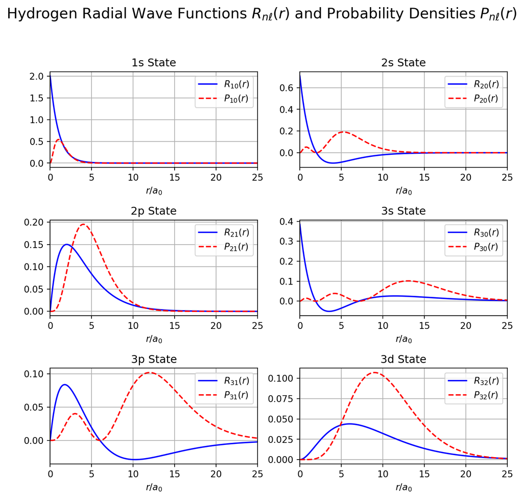

Figure 2: Radial wave functions and probability densities for low-$n$ states.

```python
import numpy as np
import matplotlib.pyplot as plt

# Define the Bohr radius
a0 = 1.0

def R_10(r):
    """
    1s radial wavefunction.
    """
    return 2 * (a0**(-1.5)) * np.exp(-r / a0)

def R_20(r):
    """
    2s radial wavefunction.
    """
    return (1 / (2 * np.sqrt(2))) * (a0**(-1.5)) * (2 - r / a0) * np.exp(-r / (2 * a0))

def R_21(r):
    """
    2p radial wavefunction.
    """
    return (1 / (2 * np.sqrt(6))) * (a0**(-1.5)) * (r / a0) * np.exp(-r / (2 * a0))

def R_30(r):
    """
    3s radial wavefunction.
    """
    return (2 / (81 * np.sqrt(3))) * (a0**(-1.5)) * (27 - 18 * (r / a0) + 2 * (r / a0)**2) * np.exp(-r / (3 * a0))

def R_31(r):
    """
    3p radial wavefunction.
    """
    return (4 / (81 * np.sqrt(6))) * (a0**(-1.5)) * (6 - r / a0) * (r / a0) * np.exp(-r / (3 * a0))

def R_32(r):
    """
    3d radial wavefunction.
    """
    return (4 / (81 * np.sqrt(30))) * (a0**(-1.5)) * (r / a0)**2 * np.exp(-r / (3 * a0))

def P(R, r):
    """
    Calculates the radial probability density P(r) = r^2 * |R(r)|^2
    """
    return r**2 * np.abs(R)**2

# Create a range of r values
r_values = np.linspace(0, 25 * a0, 500)

# Set up the plot
fig, axes = plt.subplots(3, 2, figsize=(8, 8))
fig.suptitle("Hydrogen Radial Wave Functions $R_{n\ell}(r)$ and Probability Densities $P_{n\ell}(r)$", fontsize=16)

# Plot for 1s state
ax1 = axes[0, 0]
ax1.set_title("1s State")
ax1.plot(r_values, R_10(r_values), label='$R_{10}(r)$', color='blue')
ax1.plot(r_values, P(R_10(r_values), r_values), label='$P_{10}(r)$', color='red', linestyle='--')
ax1.set_xlabel('$r/a_0$')
ax1.set_xlim(0, 25)
ax1.legend()
ax1.grid(True)

# Plot for 2s state
ax2 = axes[0, 1]
ax2.set_title("2s State")
ax2.plot(r_values, R_20(r_values), label='$R_{20}(r)$', color='blue')
ax2.plot(r_values, P(R_20(r_values), r_values), label='$P_{20}(r)$', color='red', linestyle='--')
ax2.set_xlabel('$r/a_0$')
ax2.set_xlim(0, 25)
ax2.legend()
ax2.grid(True)

# Plot for 2p state
ax3 = axes[1, 0]
ax3.set_title("2p State")
ax3.plot(r_values, R_21(r_values), label='$R_{21}(r)$', color='blue')
ax3.plot(r_values, P(R_21(r_values), r_values), label='$P_{21}(r)$', color='red', linestyle='--')
ax3.set_xlabel('$r/a_0$')
ax3.set_xlim(0, 25)
ax3.legend()
ax3.grid(True)

# Plot for 3s state
ax4 = axes[1, 1]
ax4.set_title("3s State")
ax4.plot(r_values, R_30(r_values), label='$R_{30}(r)$', color='blue')
ax4.plot(r_values, P(R_30(r_values), r_values), label='$P_{30}(r)$', color='red', linestyle='--')
ax4.set_xlabel('$r/a_0$')
ax4.set_xlim(0, 25)
ax4.legend()
ax4.grid(True)

# Plot for 3p state
ax5 = axes[2, 0]
ax5.set_title("3p State")
ax5.plot(r_values, R_31(r_values), label='$R_{31}(r)$', color='blue')
ax5.plot(r_values, P(R_31(r_values), r_values), label='$P_{31}(r)$', color='red', linestyle='--')
ax5.set_xlabel('$r/a_0$')
ax5.set_xlim(0, 25)
ax5.legend()
ax5.grid(True)

# Plot for 3d state
ax6 = axes[2, 1]
ax6.set_title("3d State")
ax6.plot(r_values, R_32(r_values), label='$R_{32}(r)$', color='blue')
ax6.plot(r_values, P(R_32(r_values), r_values), label='$P_{32}(r)$', color='red', linestyle='--')
ax6.set_xlabel('$r/a_0$')
ax6.set_xlim(0, 25)
ax6.legend()
ax6.grid(True)

# Adjust layout and show the plot
plt.tight_layout(rect=[0, 0.03, 1, 0.95])
plt.show()
```

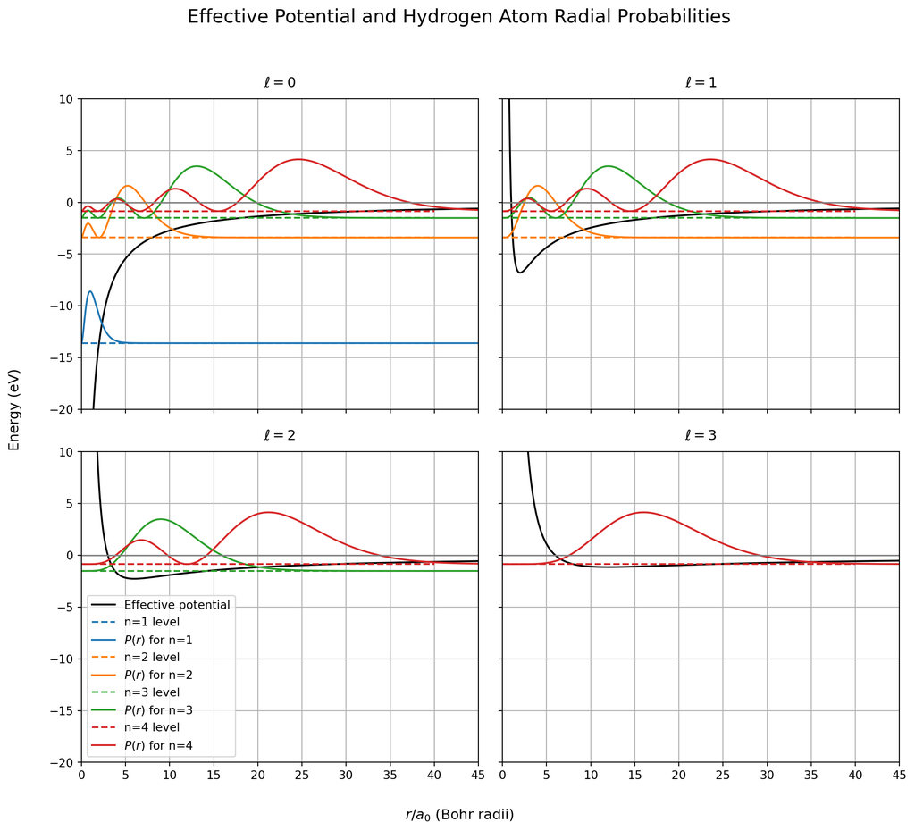

Figure 3: Radial wave probability densities in the effective potential for different $\ell$.

```python
import numpy as np
import matplotlib.pyplot as plt
from scipy.constants import physical_constants
from scipy.special import genlaguerre, factorial

# Constants
a0 = physical_constants["Bohr radius"][0]      # Bohr radius [m]
Eh = physical_constants["Hartree energy"][0]   # Hartree energy [J]
eV = physical_constants["electron volt"][0]    # 1 eV in J

nmax = 4

# General hydrogen radial wavefunction R_{nl}(r)
def R_nl(r, n, l):
    if l >= n or l < 0:
        raise ValueError("Quantum number l must satisfy 0 <= l < n")
    rho = 2 * r / (n * a0)
    norm = np.sqrt((2/(n*a0))**3 * factorial(n-l-1)/(2*n*factorial(n+l)))
    return norm * rho**l * np.exp(-rho/2) * genlaguerre(n-l-1, 2*l+1)(rho)

# Radial probability densities P(r) = r^2 |R_{nl}(r)|^2
def P_n(r, n, l):
    R = R_nl(r, n, l)
    return r**2 * np.abs(R)**2

# Energy levels [J]
def energy_n(n):
    return -Eh / (2 * n**2)

# Effective potential (Coulomb + centrifugal)
def V_r(r, l):
    return -Eh * a0 / r + Eh * a0**2 * l*(l+1) / (2 * r**2)

# Prepare data
r = np.linspace(0.01*a0, 60*a0, 2000)  # radial range

# Colors
prop_cycle = plt.rcParams['axes.prop_cycle']
colors = prop_cycle.by_key()['color']

# Set up 2x2 subplots
fig, axes = plt.subplots(2, 2, figsize=(11, 10), sharex=True, sharey=True)
axes = axes.flatten()

for idx, myell in enumerate(range(4)):   # l = 0,1,2,3
    ax = axes[idx]

    # Effective potential
    V = V_r(r, myell) / eV
    ax.plot(r/a0, V, 'k', label="Effective potential")

    # Energy levels + radial probabilities
    for i, n in enumerate(range(myell+1, nmax+1)):
        E = energy_n(n)/eV
        ax.hlines(E, 0, 40, colors=colors[n-1], linestyles='--', label=f"n={n} level")

        P = P_n(r, n, myell)
        P_scaled = (P/np.max(P)) * 5 + E  # scale & shift to energy level
        ax.plot(r/a0, P_scaled, colors[n-1], label=f"$P(r)$ for n={n}")

    # E=0 line
    ax.axhline(0, color='gray', linewidth=1.2)

    ax.set_xlim(0, 45)
    ax.set_ylim(-20, 10)
    ax.set_title(fr"$\ell={myell}$", pad=10)
    ax.grid(True)

# Force ticks to show up only where wanted
for ax in axes:
    ax.tick_params(labelbottom=False, labelleft=False)  # start blank

# left column: y labels
axes[0].tick_params(labelleft=True)
axes[2].tick_params(labelleft=True)

# bottom row: x labels
axes[2].tick_params(labelbottom=True)
axes[3].tick_params(labelbottom=True)

# Shared axis labels (outside the plots)
fig.text(0.5, 0.01, r"$r/a_0$ (Bohr radii)", ha="center", fontsize=12)
fig.text(0.01, 0.5, "Energy (eV)", va="center", rotation="vertical", fontsize=12)

# Legend only in bottom-left subplot
handles, labels = axes[0].get_legend_handles_labels()
axes[2].legend(handles, labels, loc="lower left", fontsize=10)

fig.suptitle("Effective Potential and Hydrogen Atom Radial Probabilities", fontsize=16)
plt.tight_layout(rect=[0.04,0.04,1,0.95])
plt.show()
```

# 5. Remarks on degeneracy and physical interpretation

- The energy $E_n$ depends only on $n$ (not on $\ell$ or $m$) for the non-relativistic Coulomb problem.  
  Thus each energy level has the well-known degeneracy $n^2$, meaning there are $n^2$ orthonormal eigenstates of the Hamiltonian with the same eigenvalue:

  $$\sum_{\ell=0}^{n-1} (2\ell+1)
  = 2\sum_{\ell=0}^{n-1} \ell + \sum_{\ell=0}^{n-1} 1
  = (n-1)n + n
  = n^2.$$

  The *accidental* degeneracy with respect to $\ell$ (states of different orbital angular momentum but the same $n$ having equal energy) is related to the existence of an additional conserved vector in the Coulomb problem, the **Runge–Lenz vector**.
- The centrifugal term $\hbar^2\ell(\ell+1)/(2 m r^2)$ explains qualitative radial behavior:
  - Larger $\ell$ suppresses probability density near the nucleus (nodes and behavior near $r=0$).
  - For $\ell=0$ (s-states) the wavefunction is nonzero at the origin.
- The quantization condition emerged here from the requirement of normalizable solutions (polynomial termination of a confluent hypergeometric series). This is the standard quantum analogue of Bohr’s quantization in the old theory and yields the same energy formula.

# 6. Atomic states in Dirac notation

In the hydrogen atom, the solutions of the Schrödinger equation are labeled by the three quantum numbers:

**TipAtomic quantum numbers**

- the **principal quantum number** $n = 1,2,3,\dots$,
- the **orbital angular momentum quantum number** $\ell = 0,1,\dots,n-1$,
- the **magnetic quantum number** $m = -\ell, -\ell+1, \dots, \ell$.

A complete set of eigenstates of the Hamiltonian can therefore be denoted as

$$|n,\ell,m\rangle.$$

These states satisfy the following eigenvalue equations:

**TipEigenvalue equations**

$$\hat H |n,\ell,m\rangle = E_n |n,\ell,m\rangle,$$

$$\hat L^2 |n,\ell,m\rangle = \hbar^2 \ell(\ell+1) |n,\ell,m\rangle,$$

$$\hat L_z |n,\ell,m\rangle = \hbar m |n,\ell,m\rangle.$$

The wavefunctions in position space are related to these kets by

$$\psi_{n\ell m}(\vec r) \;=\; \langle \vec r \,|\, n,\ell,m \rangle,$$

with the explicit form

$$\psi_{n\ell m}(r,\theta,\varphi) = R_{n\ell}(r)\, Y_\ell^m(\theta,\varphi),$$

where $R_{n\ell}(r)$ is the radial wavefunction and $Y_\ell^m(\theta,\varphi)$ are the spherical harmonics.

**Why Dirac notation?**  
We will use the compact ket notation $|n,\ell,m\rangle$ throughout the following discussions, since it highlights the algebraic properties (eigenvalues, degeneracies, operator actions) without always writing out the full coordinate-space wavefunctions.

# 7. Orbital Naming Conventions

In quantum mechanics, the orbital angular momentum quantum number $\ell$ dictates the shape of an electron’s orbital and gives rise to a specific naming convention. These are the common designations for the first few values of $\ell$:

- $\ell = 0$: **s-state** (from “sharp”)
- $\ell = 1$: **p-state** (from “principal”)
- $\ell = 2$: **d-state** (from “diffuse”)
- $\ell = 3$: **f-state** (from “fundamental”)

This nomenclature is a historical convention from early spectroscopy, where these letters corresponded to the appearance of certain series of spectral lines: sharp, principal, diffuse, and fundamental.

# Appendix: useful expressions

- Bohr radius:
  $$a_0 = \frac{4\pi\varepsilon_0 \hbar^2}{m e^2}.$$
- Rydberg energy:
  $$R_\mathrm{y} = \frac{m e^4}{2(4\pi\varepsilon_0)^2 \hbar^2}.$$
- Energy levels:
  $$E_n = -\frac{R_\mathrm{y} Z^2}{n^2},\qquad n=1,2,\dots$$